# Lab 5, Maria Chernyavskaya, Section AB

## Lab 5 Instructions

1. Getting started (don't turn in, but think)

   A. Pick and download your data

   B. Get familiar with your data, making sure you understand the axes, etc.

   C. Following the links in the data instructions, read about your instrument and how the data was taken

   D. Explore your data. Mostly make sure you understand what all of the labels mean, and make a few representative plots.
2. For your lab report, create an initial writeup of your data and what you found. Think of this as a book report, where you describe how the data was taken, what the labels mean, and how to interpret the first plots you've made. This will need to be several pages long.

For this series of labs, I have chosen a data set from HERA. To start exploring the data, I read the HERA data manual (Dara Storer) we were provided. The manual states that the data was collected by the HERA radio telescope. HERA stands for Hydrogen Epoch of Reoinization Array. Before I dive into the instrument and how the data was taken, I must give background (ba dum ts) on what the instrument itself measures.

In astronomy, hydrogen plays an important role, specifically telling us about regions of space and what kind of star formation is happening there, if any. When a neutral hydrogen's electron changes its energy state (spin flip), an emission of energy 5.87433 μeV ($9.411708 * 10^−25$ J) leaves the atom. This phenomenon is called the hydrogen line, 21-centimeter line or H I line. This line often appears as a spectra in the radio spectrum (in the L band of the UHF band). Because of the range of the energy, it can easily pass through the Earth's atmosphere and be observed from the ground with little sky-sourced interference. Of course, current technology gets in the way (radios, cell towers, etc), but telescopes like HERA are built in remote places to try to avoid this as much as possible.

The 21cm line is used to determine the rotational curve of the galaxy, as hydrogen is everywhere in the universe, and the only difference in the 21cm lines they emit is the doppler shift that has affected it (because space stretches. This is a cosmology-related thing, and not quite relevant to the lab, so I will not discuss this further). Through this, galaxy mass can also be calculated. Because of how "easy" it is to observe from ground, this line is often used in Big Bang cosmology. It is used to learn about the universe at large redshifts (really long ago). Of particular interest are the recombination and reionization phases. Including redshift, this line is observed at frequencies from roughly 200 MHz to 9 MHz on Earth. One of the things that it is used for is mapping the intensity of reddshift, which allows analysis of how reionization happened in the universe (neutral hydrogen that was ionized doesn't emit 21 cm lines). More information can be found here: https://en.wikipedia.org/wiki/Hydrogen_line.

Now that we have established why we care about hydrogen, let's talk about HERA. HERA is a radio telescope, which works similar to the way satellite TV dishes work, except much larger, and instead of just one dish, HERA is a 'network' of such dishes. This set-up is called an interferometer. The principle is that all the dishes (antennas) receive signals and send the to a central supercomputer, the correlator. The correlator takes the signals and compares them against all the other antennas. The idea is that this will create either constructive or destructive interference, and that there is meaning in the patterns this creates. Interferometers allow for high resolution over a large area, and that is the advantage of using them.

I will quote the data manual here, as it succinctly explains what the data in the set is:

"For HERA, the dishes are arranged in hexagonal arrays - see https://reionization.org/science/technical-design/ for images/visualization of this.

### Baseline

A baseline refers to a pair of dishes. The length and orientation of a baseline is given by the separation vector between the two dishes.

### Visibility

A visibility is the actual data product we will look at. Visibilities essentially a measure of the response of a particular baseline to incoming radiation from the sky. So, our final data product will contain a measurement of the visibility for each baseline in the array. Note: the visibilities are complex numbers - you may want to think about the best way to deal with that.

There are two "types" of visibilities: cross-correlations and auto-correlations. Cross-correlations are visibilities corresponding to a baseline between two different antennas, which is the primary data product. Auto-correlations are visibilities corresponding to the correlation between an antenna and itself. Auto-correlations are not typically used for "science", but they can be useful in diagnosing problems with individual antennas, because they only contain information from one antenna.

### Some more useful info

HERA collects data between 100Mhz and 200Mhz, and for four different polarizations (XX, YY, XY, YX). Therefore, the data product you look at will contain visibilities for each baseline, frequency, polarization, and time. The files uploaded here are only a small portion of a night, so the time axis won't be tremendously long. One particularly useful aspect of the data is that we expect sky signals to be quite steady in time (no rapid changes) - keep this in mind when you are hunting for non-sky effects! " (HERA data manual).

Now (finally), for some data exploration!

```python
# import pyuvdata everytime for JupyterHub
! conda install pyuvdata -y > /dev/null
```

[output not shown]

```python
from pyuvdata import UVData
import numpy as np
from matplotlib import pyplot as plt
import scipy
from scipy import stats
plt.rcParams["figure.figsize"] = (10,6)
```

```python
uv = UVData()
uv.read('/home/jovyan/Phys434_BigData/zen.2459122.62018.mini.sum.uvh5')
data = uv.data_array
print('This data array has the following shape:')
print(f'{np.shape(data)[0]} baselines*times, {np.shape(data)[1]} spectral windows, {np.shape(data)[2]} frequencies, {np.shape(data)[3]} polarizations')
```

```
This data array has the following shape:
13320 baselines*times, 1 spectral windows, 1536 frequencies, 1 polarizations
```

## Primary info

What does this mean? The baselines * times refers to the baselines (defined above) multiplied by the different times the data was taken at. The spectral window means all the data is in one part of the electromagnetic spectrum. There are 1536 frequencies of emission present, and all of it in 1 polarization, the XX, which the manual mentioned. Now, let's look at the antennas in the array, and look at the correlations:

```python
# Look at the antennas that are contained in the array, and count them:
print(sorted(uv.antenna_numbers))
print(f"\nThere are {len(uv.antenna_numbers)} antennas here.")
```

```
[0, 1, 2, 11, 12, 13, 14, 23, 24, 25, 26, 36, 37, 38, 39, 44, 45, 46, 50, 51, 52, 53, 58, 59, 65, 66, 67, 68, 73, 75, 81, 82, 83, 84, 85, 86, 87, 88, 89, 90, 91, 92, 93, 94, 98, 99, 100, 101, 102, 103, 104, 105, 107, 108, 109, 110, 111, 112, 116, 117, 118, 119, 120, 121, 122, 123, 124, 127, 128, 129…

There are 104 antennas here.
```

## Cross-correlation

Why cross-correlation? Cross-correlation is the main principle of interferometry, where comparison of different signals gives us information about the signal (constructive and destructive interference)

I am going to pick antennas 140 and 23 to follow the manual to see that it works:

```python
# Pick 2 sample antennas, and get data from that baseline. Note that to get the 'auto-correlations', you can do the
# same thing, but set antenna1 and antenna2 to be the same value.
antenna1 = 140
antenna2 = 23
data = uv.get_data(antenna1,antenna2)
```

The plot below is a waterfall plot, it shows evolution with time. I decided to also take the log base 10 (astronomy tends to have base ten logs in it) of the absolute value of the data to see the difference in values more:

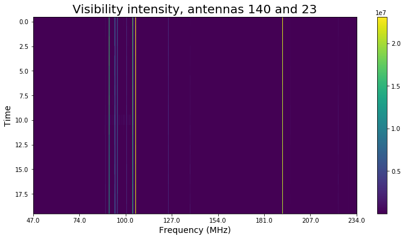

```python
fig, axs = plt.subplots(1,1,figsize=(12,6))
im = plt.imshow(np.abs(data), aspect='auto')
cbar = fig.colorbar(im)
freqs = uv.freq_array[0]*1e-6 #gets frequencies associated with each channel, in MHz
axs.set_ylabel('Time', fontsize = 14)
axs.set_xlabel('Frequency (MHz)', fontsize = 14)
xticks = [int(i) for i in np.linspace(0,len(freqs)-1,8)]
_ = axs.set_xticks(xticks)
xticklabels = np.around(freqs[xticks],0)
_ = axs.set_xticklabels(xticklabels)
axs.set_title("Visibility intensity, antennas 140 and 23", fontsize= 20);
```

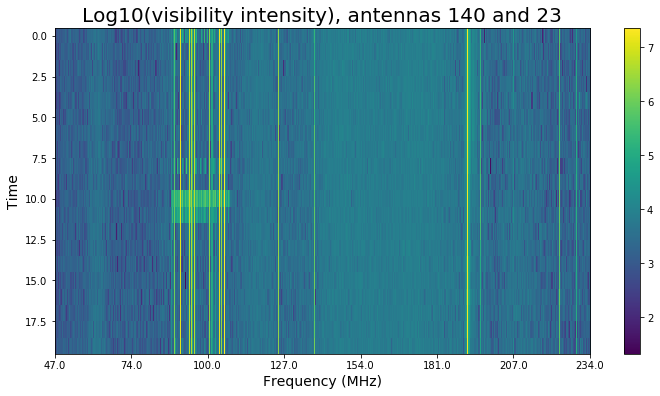

```python
fig, axs = plt.subplots(1,1,figsize=(12,6))
im = plt.imshow(np.log10(np.abs(data)), aspect='auto')
cbar = fig.colorbar(im)
freqs = uv.freq_array[0]*1e-6 #gets frequencies associated with each channel, in MHz
axs.set_ylabel('Time', fontsize = 14)
axs.set_xlabel('Frequency (MHz)', fontsize = 14)
xticks = [int(i) for i in np.linspace(0,len(freqs)-1,8)]
_ = axs.set_xticks(xticks)
xticklabels = np.around(freqs[xticks],0)
_ = axs.set_xticklabels(xticklabels)
axs.set_title("Log10(visibility intensity), antennas 140 and 23", fontsize= 20);
```

## Auto-correlation

Let's look at the same kind of plots, but an autocorrelation, to see if anything different/ hidden shows up:

```python
antenna1 = 23
antenna2 = 23
data = uv.get_data(antenna1,antenna2)
```

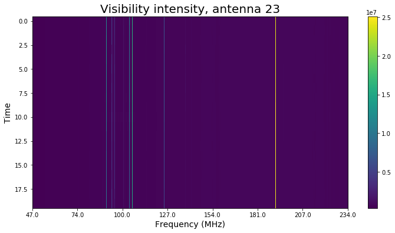

```python
fig, axs = plt.subplots(1,1,figsize=(12,6))
im = plt.imshow(np.abs(data), aspect='auto', interpolation = 'nearest')
cbar = fig.colorbar(im)
freqs = uv.freq_array[0]*1e-6 #gets frequencies associated with each channel, in MHz
axs.set_ylabel('Time', fontsize = 14)
axs.set_xlabel('Frequency (MHz)', fontsize = 14)
xticks = [int(i) for i in np.linspace(0,len(freqs)-1,8)]
_ = axs.set_xticks(xticks)
xticklabels = np.around(freqs[xticks],0)
_ = axs.set_xticklabels(xticklabels)
axs.set_title("Visibility intensity, antenna 23", fontsize= 20);
```

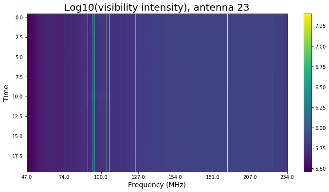

```python
fig, axs = plt.subplots(1,1,figsize=(12,6))
im = plt.imshow(np.log10(np.abs(data)), aspect='auto',interpolation = 'nearest')
cbar = fig.colorbar(im)
freqs = uv.freq_array[0]*1e-6 #gets frequencies associated with each channel, in MHz
axs.set_ylabel('Time', fontsize = 14)
axs.set_xlabel('Frequency (MHz)', fontsize = 14)
xticks = [int(i) for i in np.linspace(0,len(freqs)-1,8)]
_ = axs.set_xticks(xticks)
xticklabels = np.around(freqs[xticks],0)
_ = axs.set_xticklabels(xticklabels)
axs.set_title("Log10(visibility intensity), antenna 23", fontsize= 20);
```

These plots look very similar to the cross-correlation ones above, so I think it doesn't actually tell us anything new, except for just how much dimmer the background looks here versus the 140 and 23 cross-correlation. I think that's because we're dealing with the same antenna. These two plots also show us that time does not affect the signal for the most part- the lines seem to be of equal strength all the way down. The very very faint color "stretch" around time 10 which we saw before is still here, so going forward, I will look at that time carefully.

Now, I'm going to try to suss out which antennas are broken. The way I'm doing that is comparing the output signals from each antenna and plot them in a frequency vs visibility intensity at a specific time. I have chosen time 5 because it looked like there were no weird phenomena going on then.

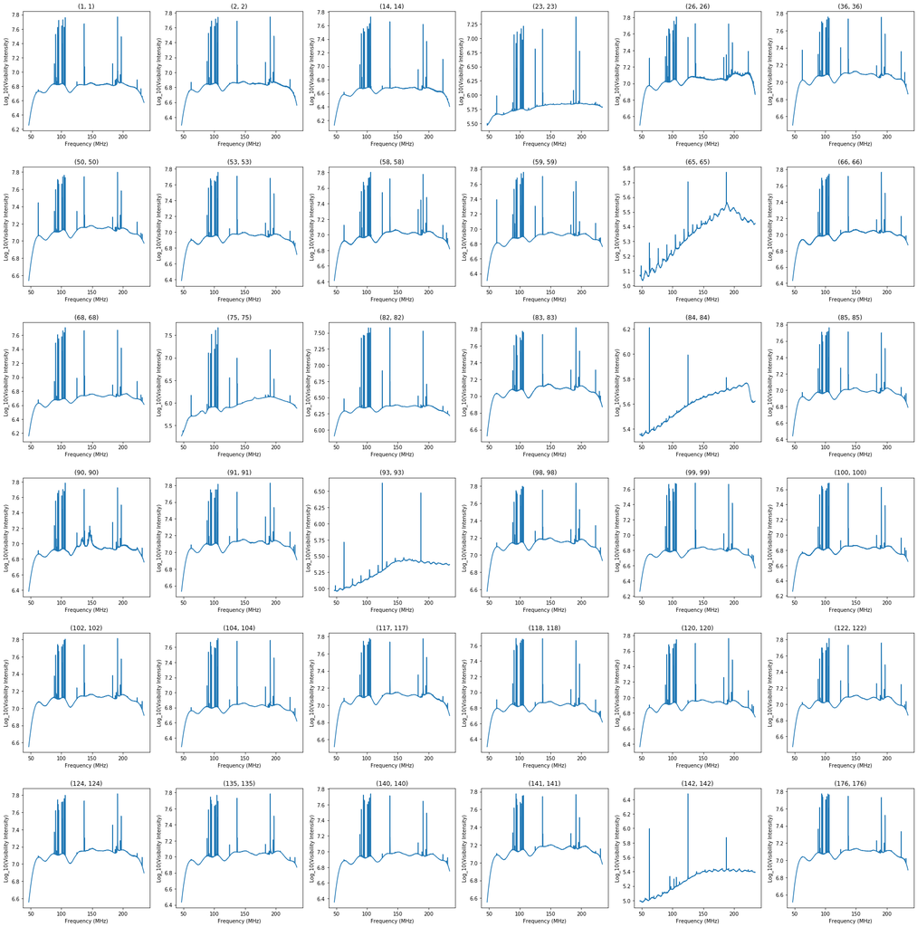

```python
sa=[]
pairs = uv.get_antpairs()
for i in range(len(pairs)):
    if pairs[i][0]==pairs[i][1]:
        sa.append(pairs[i])
len(sa)

fig,ax=plt.subplots(6,6,figsize=(25,25))
fig.tight_layout(w_pad=2, h_pad=5)
ax=ax.flatten()
for i in range(36):
    pr=sa[i]
    dat = uv.get_data(pr)
    ax[i].set_title(pr)
    ax[i].plot(freqs,np.log10(abs(dat[5])))
    ax[i].set_xlabel('Frequency (MHz)')
    ax[i].set_ylabel('Log_10(Visibility Intensity)')
```

As you can see, most of the antennas give a similar "profile". A few of them, namely: 65,84,93, and 142 have a strikingly different look to them. A possible interpretation would be that these are the broken or malfunctioning antennas. For a little thought experiment, I will plot a baseline with one (and then both) broken antennas like we did before:

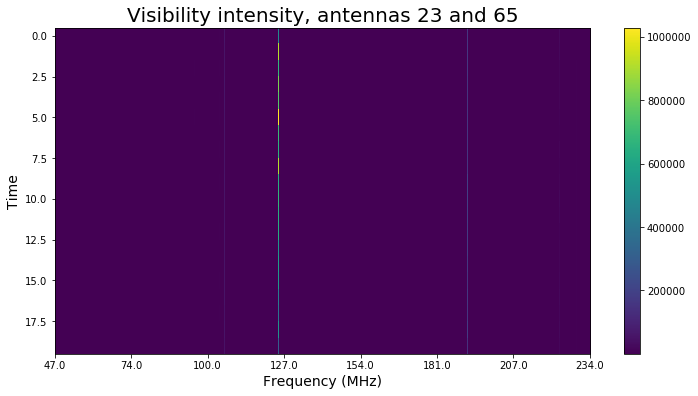

```python
antenna1 = 23
antenna2 = 65
data = uv.get_data(antenna1,antenna2)

fig, axs = plt.subplots(1,1,figsize=(12,6))
im = plt.imshow(np.abs(data), aspect='auto', interpolation = 'nearest')
cbar = fig.colorbar(im)
freqs = uv.freq_array[0]*1e-6 #gets frequencies associated with each channel, in MHz
axs.set_ylabel('Time', fontsize = 14)
axs.set_xlabel('Frequency (MHz)', fontsize = 14)
xticks = [int(i) for i in np.linspace(0,len(freqs)-1,8)]
_ = axs.set_xticks(xticks)
xticklabels = np.around(freqs[xticks],0)
_ = axs.set_xticklabels(xticklabels)
axs.set_title("Visibility intensity, antennas 23 and 65", fontsize= 20);
```

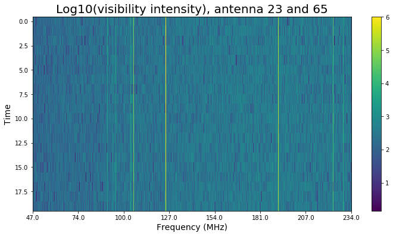

```python
fig, axs = plt.subplots(1,1,figsize=(12,6))
im = plt.imshow(np.log10(np.abs(data)), aspect='auto',interpolation = 'nearest')
cbar = fig.colorbar(im)
freqs = uv.freq_array[0]*1e-6 #gets frequencies associated with each channel, in MHz
axs.set_ylabel('Time', fontsize = 14)
axs.set_xlabel('Frequency (MHz)', fontsize = 14)
xticks = [int(i) for i in np.linspace(0,len(freqs)-1,8)]
_ = axs.set_xticks(xticks)
xticklabels = np.around(freqs[xticks],0)
_ = axs.set_xticklabels(xticklabels)
axs.set_title("Log10(visibility intensity), antenna 23 and 65", fontsize= 20);
```

The background in this "half-broken" baseline washes out the signals around 100MHz. What about a "totally" broken baseline?

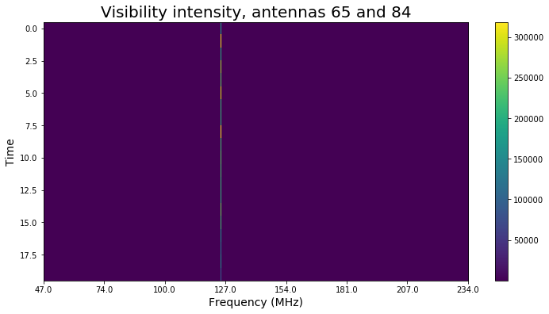

```python
antenna1 = 65
antenna2 = 84
data = uv.get_data(antenna1,antenna2)

fig, axs = plt.subplots(1,1,figsize=(12,6))
im = plt.imshow(np.abs(data), aspect='auto', interpolation = 'nearest')
cbar = fig.colorbar(im)
freqs = uv.freq_array[0]*1e-6 #gets frequencies associated with each channel, in MHz
axs.set_ylabel('Time', fontsize = 14)
axs.set_xlabel('Frequency (MHz)', fontsize = 14)
xticks = [int(i) for i in np.linspace(0,len(freqs)-1,8)]
_ = axs.set_xticks(xticks)
xticklabels = np.around(freqs[xticks],0)
_ = axs.set_xticklabels(xticklabels)
axs.set_title("Visibility intensity, antennas 65 and 84", fontsize= 20);
```

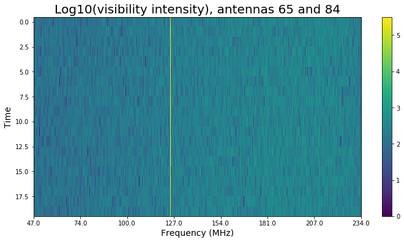

```python
fig, axs = plt.subplots(1,1,figsize=(12,6))
im = plt.imshow(np.log10(np.abs(data)), aspect='auto',interpolation = 'nearest')
cbar = fig.colorbar(im)
freqs = uv.freq_array[0]*1e-6 #gets frequencies associated with each channel, in MHz
axs.set_ylabel('Time', fontsize = 14)
axs.set_xlabel('Frequency (MHz)', fontsize = 14)
xticks = [int(i) for i in np.linspace(0,len(freqs)-1,8)]
_ = axs.set_xticks(xticks)
xticklabels = np.around(freqs[xticks],0)
_ = axs.set_xticklabels(xticklabels)
axs.set_title("Log10(visibility intensity), antennas 65 and 84", fontsize= 20);
```

## Non-sky background, possibly a phenomenon?

Time to explore that weird "stretch", or blip, around time 10, using the original pair of antennas I had. Before I do, what is this non-sky business? I think it could be interference from the ground- a cell phone tower, someone playing with a radio, and similar types of contamination. Or, it could be a signal. This depends on the sigma associated with the event, which I would have to actively analyze first. Since this is out of the scope of the lab, I will simply try to show it through plots.

```python
# Pick 2 sample antennas, and get data from that baseline. Note that to get the 'auto-correlations', you can do the
# same thing, but set antenna1 and antenna2 to be the same value.
antenna1 = 140
antenna2 = 23
data = uv.get_data(antenna1,antenna2)
```

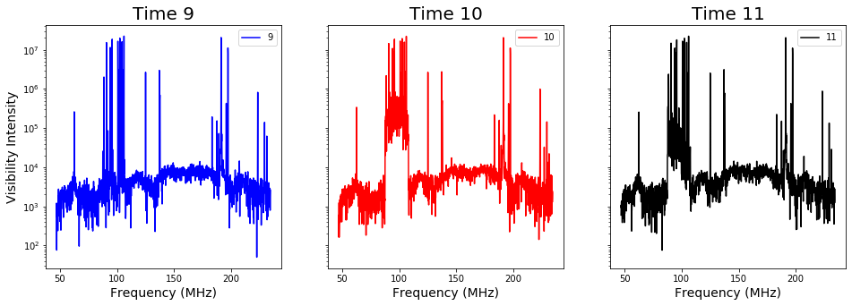

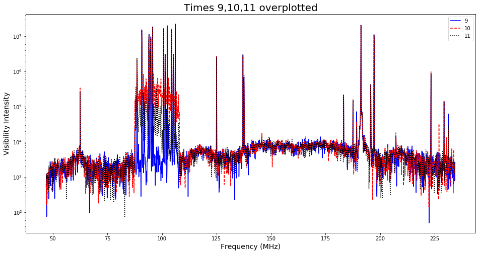

```python
fig,ax=plt.subplots(1,3,figsize=(16,5),sharey=True)
ax[0].set_yscale('log')
ax[0].plot(freqs,np.abs(data[9]), color='blue', label='9')
ax[1].set_yscale('log')
ax[1].plot(freqs,np.abs(data[10]), color='red', label='10')
ax[2].set_yscale('log')
ax[2].plot(freqs,np.abs(data[11]), color='black', label='11')
ax[0].set_ylabel("Visibility Intensity", fontsize=14)
ax[0].set_xlabel("Frequency (MHz)", fontsize = 14)
ax[1].set_xlabel("Frequency (MHz)", fontsize = 14)
ax[2].set_xlabel("Frequency (MHz)", fontsize = 14)
ax[0].set_title("Time 9", fontsize = 20)
ax[1].set_title("Time 10", fontsize = 20)
ax[2].set_title("Time 11", fontsize = 20)
ax[0].legend(loc=0)
ax[1].legend(loc=0)
ax[2].legend(loc=0);
fig,ax=plt.subplots(1,figsize=(16,8),sharey=False)
ax.set_yscale('log')
ax.plot(freqs,np.abs(data[9]), linestyle='solid', color='blue', label='9')
ax.set_yscale('log')
ax.plot(freqs,np.abs(data[10]), linestyle='dashed', color='red', label='10')
ax.set_yscale('log')
ax.plot(freqs,np.abs(data[11]), linestyle='dotted', color='black', label='11')
ax.set_ylabel("Visibility Intensity", fontsize=14)
ax.set_xlabel("Frequency (MHz)", fontsize=14)
ax.set_title("Times 9,10,11 overplotted", fontsize = 20)
ax.legend(loc=0);
```

Looking at the overplot, there's that weird part at around 100 MHz that's raised from time 9 and 10. That's the possible phenomena, and I'd have to do the same process we did with other labs to figure out whether or not it's 5 sigma. The main idea here was to show that it's a thing. The phenomena it could be, by the way, is that 21cm line that got redshifted to this state.

That was nice. What about a 2D histogram? We've used those in class before, I bet it would be useful. And it is. It gives us the general background of the baseline. The x-axis is frenquency, and the y-axis is visibility intensity. The colors represent the counts. The general "trend" in the plot is the background of the baseline:

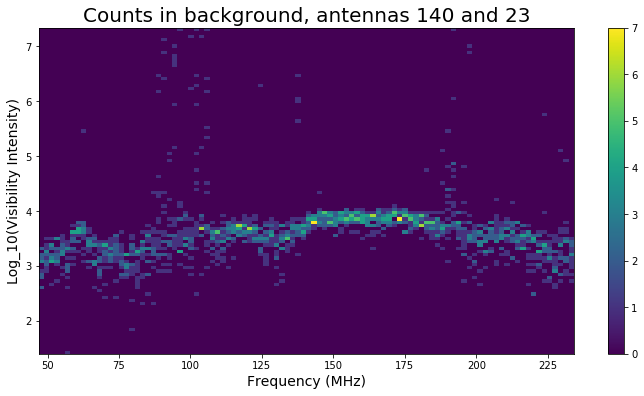

```python
fig = plt.subplots(1,1,figsize=(12,6))
for i in range(20):
    plt.hist2d(freqs, np.log10(np.abs(data[i])), bins = 100)
    plt.xlabel('Frequency (MHz)', fontsize=14)
    plt.ylabel('Log_10(Visibility Intensity)', fontsize=14)
    plt.title('Counts in background, antennas 140 and 23', fontsize=20)
plt.colorbar()
plt.show()
```